# CHAPTER 4 Dictionaries: When Indices Won't Do

## Dictionary Uses

```python
names=['Alice','Beth','Cecil','Dee-Dee','Earl']
numbers=['2341','9102','3158','0142','5551']
numbers[names.index('Cecil')]
```

```
'3158'
```

```python
phonebook['Cecil']
```

```
---------------------------------------------------------------------------
NameError                                 Traceback (most recent call last)
Cell In[4], line 1
----> 1 phonebook['Cecil']

NameError: name 'phonebook' is not defined
```

## Creating and Using Dictionaries

```python
phonebook={'Alice';'2341','Beth':'9102','Cecil';'3258'}
```

```python
phonebook['Cecil']
```

[output not shown]

字典由键及其对应值的键值对（称为条目）组成。在这个例子中，姓名是键，电话号码是值。每个键与其值之间用冒号（:）分隔，条目之间用逗号分隔，整个字典用花括号括起来。空字典（没有任何条目的字典）只用两个花括号表示，如下所示：{}。

### The dict Function

```python
items=[('name','Gumby'),('age',42)]
d=dict(items)
d
```

```
{'name': 'Gumby', 'age': 42}
```

```python
d['name']
```

```
'Gumby'
```

```python
d=dict(name='Gumby',age=42)

d
```

```
{'name': 'Gumby', 'age': 42}
```

### Basic Dictionary Operations

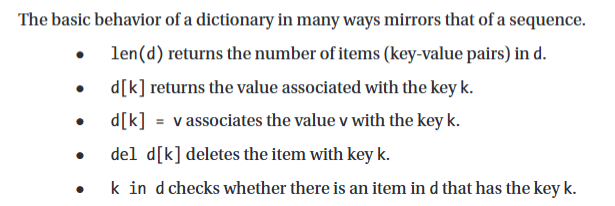

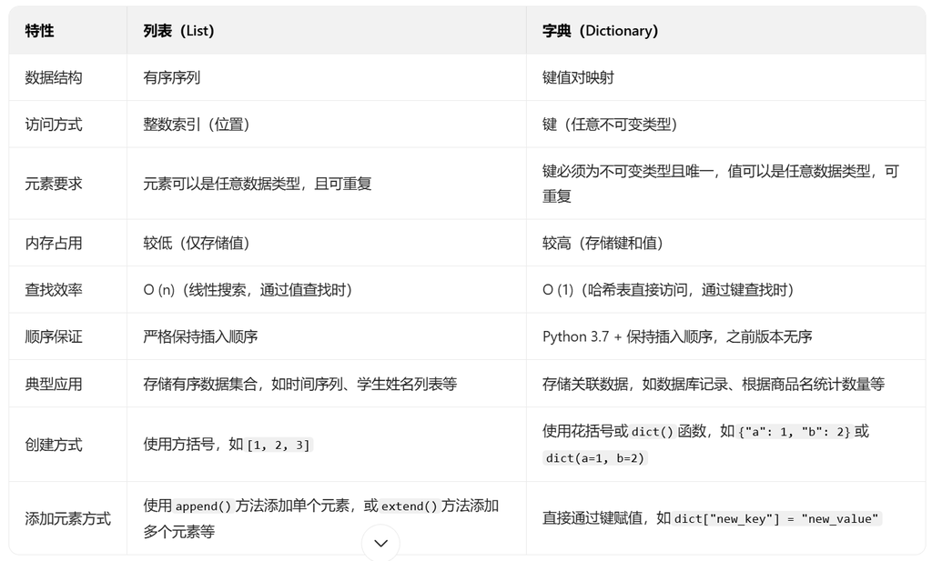

```python
x=[]   # list
x[42]='Foobar' # 尝试通过x[42] = 'Foobar'赋值
```

```
---------------------------------------------------------------------------
IndexError                                Traceback (most recent call last)
Cell In[13], line 2
      1 x=[]
----> 2 x[42]='Foobar'

IndexError: list assignment index out of range
```

```python
x={} # Dictionary
x[42]='Foobar'  # 执行x[42] = 'Foobar'可以正常工作，因为字典是键值对集合
x
```

```
{42: 'Foobar'}
```

```python
# 而使用[None] * 43初始化后，列表长度为 43，你可以通过索引 0 到 42 来访问或修改列表中的元素，这样就可以避免因索引越界而报错。
x=[None]*43
x[42]='Foobar'
x
```

[output not shown]

```python
x=[None]*43
x[42]='Foobar'
print(x)
```

```
[None, None, None, None, None, None, None, None, None, None, None, None, None, None, None, None, None, None, None, None, None, None, None, None, None, None, None, None, None, None, None, None, None, None, None, None, None, None, None, None, None, None, 'Foobar']
```

```python
# A simple database
# A dictionary with person names as keys. Each person is represented as
# another dictionary with the keys 'phone' and 'addr' referring to their phone
# number and address, respectively.
people={
    'Alice': {
        'phone':'2341',
        'addr':'Foo drive 23'
    },
    'Beth': {
        'phone':'9102',
        'addr':'Bar street 42'
    },
    'Cecil': {
        'phone':'3158',
        'addr':'Baz avenue 90'
    }
}
# Descriptive labels for the phone number and address. These will be used
# when printing the output.
labels={
    'phone':'phone number',
    'addr':'address'
}
name=input('Name: ')
# Are we looking for a phone number or an address?
request=input('Phone number (p) or address (a)?')
# Use the correct key:
if request == 'p':key='phone'
if request == 'a':key='addr'
# 两个等号 == 是因为它代表比较运算，用于判断两边的值是否相等。
# 而单个等号 = 是赋值运算，用于将右边的值赋给左边的变量
# Only try to print information iif the name is avalid key in
# our dictionary:
if name in people:print("{}'s {} is {}.".format(name, labels[key],people[name][key]))
```

```
Beth's phone number is 9102.
```

### String Formatting with Dictionaries

```python
phonebook
```

```
{'Alice': '2341', 'Beth': '9102', 'Cecil': '3258'}
```

```python
"Cecil's phone number is {Cecil}.".format_map(phonebook)
```

```
"Cecil's phone number is 3258."
```

```python
"Cecil's phone number is {Cecil}.".format(phonebook)
```

```
---------------------------------------------------------------------------
KeyError                                  Traceback (most recent call last)
Cell In[37], line 1
----> 1 "Cecil's phone number is {Cecil}.".format(phonebook)

KeyError: 'Cecil'
```

```python
"Cecil's phone number is {Cecil}.".format(**phonebook)
# 正确写法 1（使用关键字参数）：
```

```
"Cecil's phone number is 3258."
```

```python
# 正确写法 2（指定字典键）：
"Cecil's phone number is {0[Cecil]}.".format(phonebook)
```

```
"Cecil's phone number is 3258."
```

```python
template= '''<html>
 <!-- 包裹三重引号是为了保留html的各种格式 -->
<head><title>{title}</title></head>
<body>
<h1>{title}</h1>
<p>{text}</p>
</body>'''
data={'title':'My Home Page','text':'Welcome to my home page!'}
print(template.format_map(data))
```

```
<html>
 <!-- 包裹三重引号是为了保留html的各种格式 -->
<head><title>My Home Page</title></head>
<body>
<h1>My Home Page</h1>
<p>Welcome to my home page!</p>
</body>
```

### Dictionary Methods

#### clear

```python
d={}
d['name']='Gumby'
d['age']=42
d
```

```
{'name': 'Gumby', 'age': 42}
```

```python
returned_value=d.clear()
d
```

```
{}
```

```python
print(returned_value)
```

```
None
```

```python
x={}
y=x
x['key']='value'
y
```

```
{'key': 'value'}
```

```python
x={}
y
```

```
{'key': 'value'}
```

```python
x={}
y=x
x['key']='value'
y
```

```
{'key': 'value'}
```

```python
x.clear()
y
```

```
{}
```

x = {}：改变 x 的 “指向”，不影响原对象和 y； x.clear()：修改 x 指向的 “原对象内容”，所有指向该对象的变量（如 y）都会同步看到变化。

#### copy

```python
x={'username':'admin','machines':['foo','bar','baz']}
y=x.copy()
y['username']='mlh'
y['machines'].remove('bar')
y
```

```
{'username': 'mlh', 'machines': ['foo', 'baz']}
```

```python
x
```

```
{'username': 'admin', 'machines': ['foo', 'baz']}
```

如你所见，当你替换副本中的某个值时，原始数据不会受到影响。然而，如果你修改某个值（在原地修改，而非替换它），原始数据也会发生变化，因为两者存储的是同一个值（就像本例中的 “machines” 列表）。避免这个问题的一种方法是进行深拷贝，即同时拷贝值本身以及它们所包含的任何值，依此类推。你可以使用 copy 模块中的 deepcopy 函数来实现这一点。

```python
from copy import deepcopy
d={} #  表示创建一个空字典，变量名为 d
d['names']=['Alfred','Bertrand'] # 给字典 d 添加一个键为 'names' 的条目，对应的值是一个包含两个字符串元素的列表
c=d.copy()
dc=deepcopy(d)
d['names'].append('Clibe')
c
```

```
{'names': ['Alfred', 'Bertrand', 'Clibe']}
```

```python
dc
```

```
{'names': ['Alfred', 'Bertrand']}
```

#### fromkeys

```python
{}.fromkeys(['name','age'])
```

```
{'name': None, 'age': None}
```

fromkeys 方法会创建一个新字典，其中包含给定的键，每个键对应的默认值均为 None。

```python
dict.fromkeys(['name','age'])
```

```
{'name': None, 'age': None}
```

```python
# 自定义默认值
dict.fromkeys(['name','age'],'(unknown)')
```

```
{'name': '(unknown)', 'age': '(unknown)'}
```

#### get

```python
d={}
print(d['name'])
```

```
---------------------------------------------------------------------------
KeyError                                  Traceback (most recent call last)
Cell In[68], line 2
      1 d={}
----> 2 print(d['name'])

KeyError: 'name'
```

get 方法是一种容错性强的访问字典项的方式。通常情况下，当你试图访问字典中不存在的项时，会出现很严重的问题。

```python
print(d.get('name'))
```

```
None
```

```python
d.get('name','N/A')
```

```
'N/A'
```

```python
d['name']='Eric'
d.get('name')
```

```
'Eric'
```

```python
d['name']=['Eric','Florine']
d.get('name')
```

```
['Eric', 'Florine']
```

```python
# A simple database using get()
# Insert database (people0 from Listing 4-1 here
labels={
    'phone':'phone number',
    'addr':'address'
}
name=input('Name:')
# Are we looking for a phone number (p) or address (a)?
request=input('Phone number (p) or address (a)?')
# Use the correct key:
key=request # In case the request is neither 'p' nor 'a'
if request =='p':key='phone'
if request=='a':key='addr'
# Use get to privide default values:
person=people.get(name,{})
label=labels.get(key,key)
result=person.get(key,'not available')
print("{}'s {} is {}.".format(name,label,result))
```

```
Gumby's address is not available.
```

```python
# A simple database using get()
# Insert database (people0 from Listing 4-1 here
labels={
    'phone':'phone number',
    'addr':'address'
}
name=input('Name:')
# Are we looking for a phone number (p) or address (a)?
request=input('Phone number (p) or address (a)?')
# Use the correct key:
key=request # In case the request is neither 'p' nor 'a'
if request =='p':key='phone'
if request=='a':key='addr'
# Use get to privide default values:
person=people.get(name,{})
label=labels.get(key,key)
result=person.get(key,'not available')
print("{}'s {} is {}.".format(name,label,result))
```

```
Gumby's batting average is not available.
```

#### items

```python
d={'title':'Python Web Site','url':'https://www.python.org','spam':0}
d.items()
```

```
dict_items([('title', 'Python Web Site'), ('url', 'https://www.python.org'), ('spam', 0)])
```

```python
it=d.items()
len(it)
```

```
3
```

```python
('spam',0)in it
```

```
True
```

```python
d['spam']=1
('spam',0)in it
```

```
False
```

```python
d['spam']=0
('spam',0)in it
```

```
True
```

```python
list(d.items())
```

```
[('title', 'Python Web Site'), ('url', 'https://www.python.org'), ('spam', 0)]
```

#### keys

```python
list(d.keys())
```

```
['title', 'url', 'spam']
```

#### pop

```python
d={'x':1,'y':2}
d.pop('x')
```

```
1
```

```python
d
```

```
{'y': 2}
```

pop 方法可用于获取与给定键对应的值，然后从字典中删除该键值对。

#### popitem

```python
d={'url':'https://www.python.org','spam':0,'title':'Python Web Site'}
d.popitem()
```

```
('title', 'Python Web Site')
```

```python
d
```

```
{'url': 'https://www.python.org', 'spam': 0}
```

#### setdefault

```python
d={}
d.setdefault('name','N/A')
```

```
'N/A'
```

```python
d
```

```
{'name': 'N/A'}
```

```python
d={}
d.setdefault('a','b')
```

```
'b'
```

```python
d
```

```
{'a': 'b'}
```

```python
d['name']='Gumby'
d.setdefault('name','N/A')
```

```
'Gumby'
```

```python
d
```

```
{'a': 'b', 'name': 'Gumby'}
```

```python
d={}
print(d.setdefault('name'))
```

```
None
```

```python
d
```

```
{'name': None}
```

#### update

```python
d={
    'title':'python Web Site',
    'url':'https://www.python.org',
    'changes':'Oct 16 12:23:15 Met 2023'
    }
x={'title':'Python Language Website'}
d.update(x)
d
```

```
{'title': 'Python Language Website',
 'url': 'https://www.python.org',
 'changes': 'Oct 16 12:23:15 Met 2023'}
```

#### values

```python
list(d.values())
```

```
['Python Language Website',
 'https://www.python.org',
 'Oct 16 12:23:15 Met 2023']
```

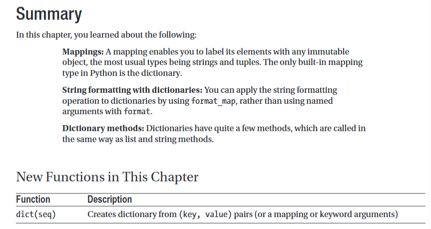